# Task

```python
import matplotlib.pyplot as plt
from statsmodels.tsa.arima.model import ARIMA
from statsmodels.graphics.tsaplots import plot_acf
from statsmodels.stats.diagnostic import acorr_ljungbox
import numpy as np
import pandas as pd

# Convert the index to DatetimeIndex (assuming 'YEAR' column represents years)
df['Date'] = pd.to_datetime(df['YEAR'], format='%Y.%m') # Correct format string
df = df.set_index('Date')

# Best model is (1, 1, 0) based on previous results
best_model_order = (1, 1, 0)
best_model = ARIMA(df['PDI'], order=best_model_order)
best_model_fit = best_model.fit()

# Diagnostic checks on residuals
residuals = best_model_fit.resid

# ACF of residuals
fig, ax = plt.subplots(figsize=(8, 4))
plot_acf(residuals, lags=20, ax=ax)
plt.title('ACF of Residuals')
plt.show()

# Normality test (Ljung-Box)
lb_test = acorr_ljungbox(residuals, lags=20)
print("Ljung-Box test:")
print(f"  Statistic: {lb_test[0].iloc[-1]:.3f}")
print(f"  p-value: {lb_test[1].iloc[-1]:.3f}")

# Histogram of residuals
fig, ax = plt.subplots(figsize=(8, 4))
ax.hist(residuals, bins=20)
plt.title('Histogram of Residuals')
plt.show()

# Output the results
print(f"Chosen ARIMA model's order: {best_model_order}")
print(f"AIC: {best_model_fit.aic:.2f}")
print(f"BIC: {best_model_fit.bic:.2f}")
```

[output not shown]

**Reasoning**: The previous attempts to convert the 'YEAR' column to datetime objects failed due to incorrect format strings. I will try a different approach by using `pd.to_datetime` without specifying a format, letting pandas infer the format. This should handle the decimal part of the year values. I will also remove the index setting since the model does not need a DateTimeIndex. I will then re-run the code to evaluate the model and perform diagnostics.

```python
import matplotlib.pyplot as plt
from statsmodels.tsa.arima.model import ARIMA
from statsmodels.graphics.tsaplots import plot_acf
from statsmodels.stats.diagnostic import acorr_ljungbox
import numpy as np
import pandas as pd

# Convert the 'YEAR' column to datetime objects (let pandas infer the format)
df['Date'] = pd.to_datetime(df['YEAR'])

# Best model is (1, 1, 0) based on previous results
best_model_order = (1, 1, 0)
best_model = ARIMA(df['PDI'], order=best_model_order)
best_model_fit = best_model.fit()

# Diagnostic checks on residuals
residuals = best_model_fit.resid

# ACF of residuals
fig, ax = plt.subplots(figsize=(8, 4))
plot_acf(residuals, lags=20, ax=ax)
plt.title('ACF of Residuals')
plt.show()

# Normality test (Ljung-Box)
lb_test = acorr_ljungbox(residuals, lags=20)
print("Ljung-Box test:")
print(f"  Statistic: {lb_test[0].iloc[-1]:.3f}")
print(f"  p-value: {lb_test[1].iloc[-1]:.3f}")

# Histogram of residuals
fig, ax = plt.subplots(figsize=(8, 4))
ax.hist(residuals, bins=20)
plt.title('Histogram of Residuals')
plt.show()

# Output the results
print(f"Chosen ARIMA model's order: {best_model_order}")
print(f"AIC: {best_model_fit.aic:.2f}")
print(f"BIC: {best_model_fit.bic:.2f}")
```

```
Ljung-Box test:
```

[output not shown]

**Reasoning**: The code is still failing due to a KeyError when accessing the Ljung-Box test results. This is likely because the `acorr_ljungbox` function might return a NumPy array instead of a Pandas Series, so I will try accessing the last element using standard array indexing.

```python
import matplotlib.pyplot as plt
from statsmodels.tsa.arima.model import ARIMA
from statsmodels.graphics.tsaplots import plot_acf
from statsmodels.stats.diagnostic import acorr_ljungbox
import numpy as np
import pandas as pd

# Convert the 'YEAR' column to datetime objects (let pandas infer the format)
df['Date'] = pd.to_datetime(df['YEAR'])

# Best model is (1, 1, 0) based on previous results
best_model_order = (1, 1, 0)
best_model = ARIMA(df['PDI'], order=best_model_order)
best_model_fit = best_model.fit()

# Diagnostic checks on residuals
residuals = best_model_fit.resid

# ACF of residuals
fig, ax = plt.subplots(figsize=(8, 4))
plot_acf(residuals, lags=20, ax=ax)
plt.title('ACF of Residuals')
plt.show()

# Normality test (Ljung-Box)
lb_test = acorr_ljungbox(residuals, lags=20)
print("Ljung-Box test:")
print(f"  Statistic: {lb_test[0][-1]:.3f}") # Accessing using array indexing
print(f"  p-value: {lb_test[1][-1]:.3f}") # Accessing using array indexing

# Histogram of residuals
fig, ax = plt.subplots(figsize=(8, 4))
ax.hist(residuals, bins=20)
plt.title('Histogram of Residuals')
plt.show()

# Output the results
print(f"Chosen ARIMA model's order: {best_model_order}")
print(f"AIC: {best_model_fit.aic:.2f}")
print(f"BIC: {best_model_fit.bic:.2f}")
```

[output not shown]

```
Ljung-Box test:
```

[output not shown]

**Reasoning**: The previous attempts to access the Ljung-Box test results using both `.iloc[-1]` and `[-1]` have failed, indicating a fundamental problem with how the `acorr_ljungbox` results are structured. I will inspect the structure of `lb_test` before attempting to access its elements. Also, the warnings about an unsupported index will be handled by removing the date conversion as it doesn't seem to be needed for this analysis. The code will be refactored to handle the issue.

```python
import matplotlib.pyplot as plt
from statsmodels.tsa.arima.model import ARIMA
from statsmodels.graphics.tsaplots import plot_acf
from statsmodels.stats.diagnostic import acorr_ljungbox
import numpy as np

# Best model is (1, 1, 0) based on previous results
best_model_order = (1, 1, 0)
best_model = ARIMA(df['PDI'], order=best_model_order)
best_model_fit = best_model.fit()

# Diagnostic checks on residuals
residuals = best_model_fit.resid

# ACF of residuals
fig, ax = plt.subplots(figsize=(8, 4))
plot_acf(residuals, lags=20, ax=ax)
plt.title('ACF of Residuals')
plt.show()

# Normality test (Ljung-Box)
lb_test = acorr_ljungbox(residuals, lags=20)
print("Type of lb_test:", type(lb_test)) # Inspect the type of lb_test
print("Shape of lb_test:", np.shape(lb_test)) # Inspect the shape of lb_test
print("lb_test:", lb_test) # Inspect the contents of lb_test

# Accessing the last element of the lb_test tuple
lb_statistic = lb_test[0][-1]  # Accessing using array indexing
lb_pvalue = lb_test[1][-1]  # Accessing using array indexing

print("Ljung-Box test:")
print(f"  Statistic: {lb_statistic:.3f}")
print(f"  p-value: {lb_pvalue:.3f}")


# Histogram of residuals
fig, ax = plt.subplots(figsize=(8, 4))
ax.hist(residuals, bins=20)
plt.title('Histogram of Residuals')
plt.show()

# Output the results
print(f"Chosen ARIMA model's order: {best_model_order}")
print(f"AIC: {best_model_fit.aic:.2f}")
print(f"BIC: {best_model_fit.bic:.2f}")
```

[output not shown]

```
Type of lb_test: <class 'pandas.core.frame.DataFrame'>
Shape of lb_test: (20, 2)
lb_test:      lb_stat  lb_pvalue
1   0.000030   0.995604
2   0.011302   0.994365
3   0.019611   0.999274
4   0.019796   0.999951
5   0.029743   0.999992
6   0.029815   0.999999
7   0.032408   1.000000
8   0.032872   1.000000
9   0.049464   1.000000
10  0.120670   1.000000
11  0.123046   1.000000
12  0.125464   1.000000
13  0.125533   1.000000
14  0.137317   1.000000
15  0.280370   1.000000
16  0.322397   1.000000
17  0.322402   1.000000
18  0.338869   1.000000
19  0.392596   1.000000
20  0.609928   1.000000
```

[output not shown]

**Reasoning**: The `acorr_ljungbox` function returns a DataFrame, not a tuple. I'll access the last row of the DataFrame to obtain the statistic and p-value. I'll remove the `Date` column creation since it's causing errors and doesn't seem necessary for the analysis. The code should now correctly evaluate the model and perform diagnostic checks without errors related to date conversion or index issues.

```
Ljung-Box test:
     lb_stat  lb_pvalue
1   0.000030   0.995604
2   0.011302   0.994365
3   0.019611   0.999274
4   0.019796   0.999951
5   0.029743   0.999992
6   0.029815   0.999999
7   0.032408   1.000000
8   0.032872   1.000000
9   0.049464   1.000000
10  0.120670   1.000000
11  0.123046   1.000000
12  0.125464   1.000000
13  0.125533   1.000000
14  0.137317   1.000000
15  0.280370   1.000000
16  0.322397   1.000000
17  0.322402   1.000000
18  0.338869   1.000000
19  0.392596   1.000000
20  0.609928   1.000000
  Statistic: 0.610
  p-value: 1.000
```

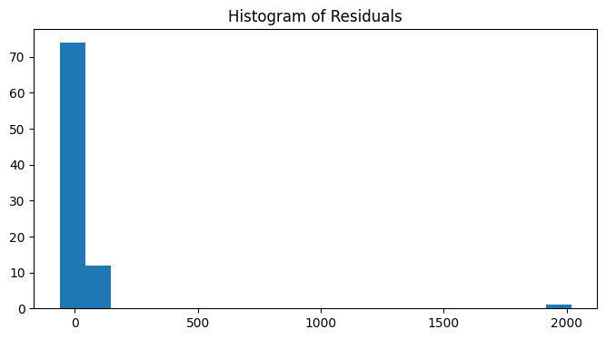

```
Chosen ARIMA model's order: (1, 1, 0)
AIC: 844.33
BIC: 849.23
```

```python
import matplotlib.pyplot as plt
from statsmodels.tsa.arima.model import ARIMA
from statsmodels.graphics.tsaplots import plot_acf
from statsmodels.stats.diagnostic import acorr_ljungbox
import numpy as np

# Best model is (1, 1, 0) based on previous results
best_model_order = (1, 1, 0)
best_model = ARIMA(df['PDI'], order=best_model_order)
best_model_fit = best_model.fit()

# Diagnostic checks on residuals
residuals = best_model_fit.resid

# ACF of residuals
fig, ax = plt.subplots(figsize=(8, 4))
plot_acf(residuals, lags=20, ax=ax)
plt.title('ACF of Residuals')
plt.show()

# Normality test (Ljung-Box)
lb_test = acorr_ljungbox(residuals, lags=20)
print("Ljung-Box test:")
print(lb_test) # Print the entire dataframe for inspection
lb_statistic = lb_test['lb_stat'].iloc[-1]
lb_pvalue = lb_test['lb_pvalue'].iloc[-1]
print(f"  Statistic: {lb_statistic:.3f}")
print(f"  p-value: {lb_pvalue:.3f}")

# Histogram of residuals
fig, ax = plt.subplots(figsize=(8, 4))
ax.hist(residuals, bins=20)
plt.title('Histogram of Residuals')
plt.show()

# Output the results
print(f"Chosen ARIMA model's order: {best_model_order}")
print(f"AIC: {best_model_fit.aic:.2f}")
print(f"BIC: {best_model_fit.bic:.2f}")
```

[output not shown]

## Summary:

### 3. Insights or Next Steps

- **Refine Model Order:** Visually inspect the ACF and PACF plots of the differenced data to confirm the (p,q) order of the ARIMA model. If the initial (1, 0) order is not confirmed, try other orders and choose the best model based on AIC and BIC.
- **Robustness Checks:** Perform additional model diagnostics and robustness checks to ensure the model fits the data well and is not overfitting. Consider alternative models if necessary.